# Risk Factor Analysis

## Outcome Variable

**Outcome Variable:** sstunted

## Predictor Variables

**Intervention Variable:** hdlvry

**Adjustment Set:**

unadjusted

## Stratifying Variables

The analysis was stratified on these variable(s):

- agecat
- studyid
- country

## Data Summary

| agecat | studyid | country | hdlvry | sstunted | n_cell | n |
| --- | --- | --- | --- | --- | --- | --- |
| Birth | ki1000108-CMC-V-BCS-2002 | INDIA | 0 | 0 | 88 | 92 |
| Birth | ki1000108-CMC-V-BCS-2002 | INDIA | 0 | 1 | 4 | 92 |
| Birth | ki1000108-CMC-V-BCS-2002 | INDIA | 1 | 0 | 0 | 92 |
| Birth | ki1000108-CMC-V-BCS-2002 | INDIA | 1 | 1 | 0 | 92 |
| Birth | ki1000108-IRC | INDIA | 0 | 0 | 365 | 388 |
| Birth | ki1000108-IRC | INDIA | 0 | 1 | 16 | 388 |
| Birth | ki1000108-IRC | INDIA | 1 | 0 | 7 | 388 |
| Birth | ki1000108-IRC | INDIA | 1 | 1 | 0 | 388 |
| Birth | ki1000109-EE | PAKISTAN | 0 | 0 | 130 | 238 |
| Birth | ki1000109-EE | PAKISTAN | 0 | 1 | 31 | 238 |
| Birth | ki1000109-EE | PAKISTAN | 1 | 0 | 60 | 238 |
| Birth | ki1000109-EE | PAKISTAN | 1 | 1 | 17 | 238 |
| Birth | ki1000304b-SAS-CompFeed | INDIA | 0 | 0 | 117 | 1085 |
| Birth | ki1000304b-SAS-CompFeed | INDIA | 0 | 1 | 7 | 1085 |
| Birth | ki1000304b-SAS-CompFeed | INDIA | 1 | 0 | 894 | 1085 |
| Birth | ki1000304b-SAS-CompFeed | INDIA | 1 | 1 | 67 | 1085 |
| Birth | ki1017093b-PROVIDE | BANGLADESH | 0 | 0 | 389 | 539 |
| Birth | ki1017093b-PROVIDE | BANGLADESH | 0 | 1 | 2 | 539 |
| Birth | ki1017093b-PROVIDE | BANGLADESH | 1 | 0 | 146 | 539 |
| Birth | ki1017093b-PROVIDE | BANGLADESH | 1 | 1 | 2 | 539 |
| Birth | ki1017093c-NIH-Crypto | BANGLADESH | 0 | 0 | 558 | 732 |
| Birth | ki1017093c-NIH-Crypto | BANGLADESH | 0 | 1 | 9 | 732 |
| Birth | ki1017093c-NIH-Crypto | BANGLADESH | 1 | 0 | 164 | 732 |
| Birth | ki1017093c-NIH-Crypto | BANGLADESH | 1 | 1 | 1 | 732 |
| Birth | ki1113344-GMS-Nepal | NEPAL | 0 | 0 | 150 | 646 |
| Birth | ki1113344-GMS-Nepal | NEPAL | 0 | 1 | 7 | 646 |
| Birth | ki1113344-GMS-Nepal | NEPAL | 1 | 0 | 469 | 646 |
| Birth | ki1113344-GMS-Nepal | NEPAL | 1 | 1 | 20 | 646 |
| Birth | ki1135781-COHORTS | INDIA | 0 | 0 | 2855 | 4694 |
| Birth | ki1135781-COHORTS | INDIA | 0 | 1 | 83 | 4694 |

[output cut: 98 more lines]

The following strata were considered:

- agecat: 24 months, studyid: ki1000108-CMC-V-BCS-2002, country: INDIA
- agecat: 24 months, studyid: ki1000108-IRC, country: INDIA
- agecat: 24 months, studyid: ki1000109-EE, country: PAKISTAN
- agecat: 24 months, studyid: ki1017093b-PROVIDE, country: BANGLADESH
- agecat: 24 months, studyid: ki1017093c-NIH-Crypto, country: BANGLADESH
- agecat: 24 months, studyid: ki1066203-TanzaniaChild2, country: TANZANIA, UNITED REPUBLIC OF
- agecat: 24 months, studyid: ki1113344-GMS-Nepal, country: NEPAL
- agecat: 24 months, studyid: ki1135781-COHORTS, country: INDIA
- agecat: 24 months, studyid: kiGH5241-JiVitA-3, country: BANGLADESH
- agecat: 24 months, studyid: kiGH5241-JiVitA-4, country: BANGLADESH
- agecat: 6 months, studyid: ki1000108-CMC-V-BCS-2002, country: INDIA
- agecat: 6 months, studyid: ki1000108-IRC, country: INDIA
- agecat: 6 months, studyid: ki1000109-EE, country: PAKISTAN
- agecat: 6 months, studyid: ki1000304b-SAS-CompFeed, country: INDIA
- agecat: 6 months, studyid: ki1000304b-SAS-FoodSuppl, country: INDIA
- agecat: 6 months, studyid: ki1017093b-PROVIDE, country: BANGLADESH
- agecat: 6 months, studyid: ki1017093c-NIH-Crypto, country: BANGLADESH
- agecat: 6 months, studyid: ki1066203-TanzaniaChild2, country: TANZANIA, UNITED REPUBLIC OF
- agecat: 6 months, studyid: ki1113344-GMS-Nepal, country: NEPAL
- agecat: 6 months, studyid: ki1135781-COHORTS, country: INDIA
- agecat: 6 months, studyid: kiGH5241-JiVitA-3, country: BANGLADESH
- agecat: 6 months, studyid: kiGH5241-JiVitA-4, country: BANGLADESH
- agecat: Birth, studyid: ki1000108-CMC-V-BCS-2002, country: INDIA
- agecat: Birth, studyid: ki1000108-IRC, country: INDIA
- agecat: Birth, studyid: ki1000109-EE, country: PAKISTAN
- agecat: Birth, studyid: ki1000304b-SAS-CompFeed, country: INDIA
- agecat: Birth, studyid: ki1017093b-PROVIDE, country: BANGLADESH
- agecat: Birth, studyid: ki1017093c-NIH-Crypto, country: BANGLADESH
- agecat: Birth, studyid: ki1113344-GMS-Nepal, country: NEPAL
- agecat: Birth, studyid: ki1135781-COHORTS, country: INDIA
- agecat: Birth, studyid: kiGH5241-JiVitA-3, country: BANGLADESH
- agecat: Birth, studyid: kiGH5241-JiVitA-4, country: BANGLADESH

### Dropped Strata

Some strata were dropped due to rare outcomes:

- agecat: Birth, studyid: ki1000108-CMC-V-BCS-2002, country: INDIA
- agecat: Birth, studyid: ki1000108-IRC, country: INDIA
- agecat: Birth, studyid: ki1017093b-PROVIDE, country: BANGLADESH
- agecat: Birth, studyid: ki1017093c-NIH-Crypto, country: BANGLADESH
- agecat: Birth, studyid: kiGH5241-JiVitA-3, country: BANGLADESH
- agecat: 6 months, studyid: ki1000108-CMC-V-BCS-2002, country: INDIA
- agecat: 6 months, studyid: ki1000108-IRC, country: INDIA
- agecat: 6 months, studyid: ki1017093c-NIH-Crypto, country: BANGLADESH
- agecat: 6 months, studyid: ki1066203-TanzaniaChild2, country: TANZANIA, UNITED REPUBLIC OF
- agecat: 6 months, studyid: ki1113344-GMS-Nepal, country: NEPAL
- agecat: 6 months, studyid: kiGH5241-JiVitA-3, country: BANGLADESH
- agecat: 24 months, studyid: ki1000108-CMC-V-BCS-2002, country: INDIA
- agecat: 24 months, studyid: ki1000108-IRC, country: INDIA
- agecat: 24 months, studyid: ki1066203-TanzaniaChild2, country: TANZANIA, UNITED REPUBLIC OF
- agecat: 24 months, studyid: kiGH5241-JiVitA-3, country: BANGLADESH

## Methods Detail

We’re interested in the causal parameters $E[Y_a]$ for all values of $a \in \mathcal{A}$. These parameters represent the mean outcome if, possibly contrary to fact, we intervened to set all units to have $A=a$. Under the randomization and positivity assumptions, these are identified by the statistical parameters $\psi_a=E_W[E_{Y|A,W}(Y|A=a,W)]$. In addition, we’re interested in the mean of $Y$, $E[Y]$ under no intervention (the observed mean). We will estimate these parameters by using SuperLearner to fit the relevant likelihood factors – $E_{Y|A,W}(Y|A=a,W)$ and $p(A=a|W)$, and then updating our likelihood fit using a joint TMLE.

For unadjusted analyses ($W=\{\}$), initial likelihoods were estimated using Lrnr_glm to estimate the simple $E(Y|A)$ and Lrnr_mean to estimate $p(A)$. For adjusted analyses, a small library containing Lrnr_glmnet, Lrnr_xgboost, and Lrnr_mean was used.

Having estimated these parameters, we will then use the delta method to estimate relative risks and attributable risks relative to a prespecified baseline level of $A$.

# Results Detail

## Results Plots

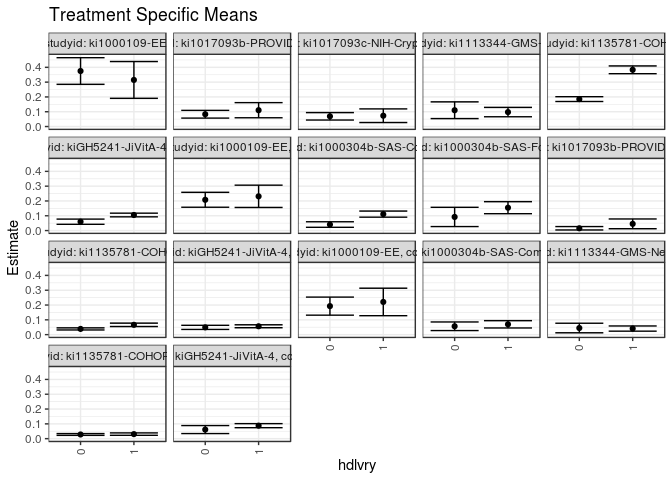

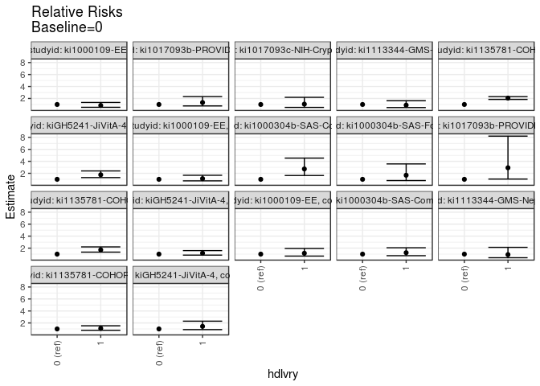

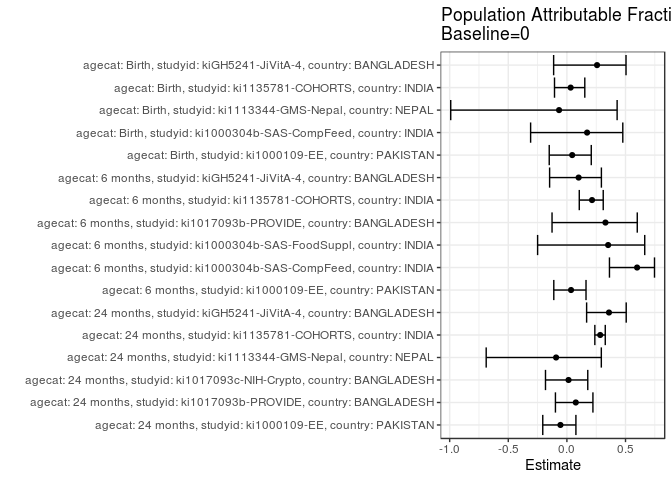

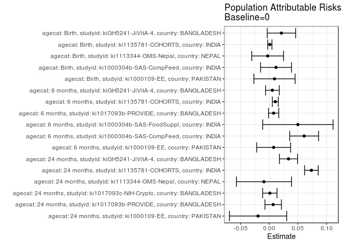

## Results Table

### Parameter: TSM

| agecat | studyid | country | intervention_level | baseline_level | estimate | ci_lower | ci_upper |
| --- | --- | --- | --- | --- | --- | --- | --- |
| Birth | ki1000109-EE | PAKISTAN | 0 | NA | 0.1925466 | 0.1315120 | 0.2535812 |
| Birth | ki1000109-EE | PAKISTAN | 1 | NA | 0.2207792 | 0.1279411 | 0.3136174 |
| Birth | ki1000304b-SAS-CompFeed | INDIA | 0 | NA | 0.0564516 | 0.0274585 | 0.0854447 |
| Birth | ki1000304b-SAS-CompFeed | INDIA | 1 | NA | 0.0697190 | 0.0451096 | 0.0943285 |
| Birth | ki1113344-GMS-Nepal | NEPAL | 0 | NA | 0.0445860 | 0.0122765 | 0.0768954 |
| Birth | ki1113344-GMS-Nepal | NEPAL | 1 | NA | 0.0408998 | 0.0233318 | 0.0584678 |
| Birth | ki1135781-COHORTS | INDIA | 0 | NA | 0.0282505 | 0.0222587 | 0.0342423 |
| Birth | ki1135781-COHORTS | INDIA | 1 | NA | 0.0307517 | 0.0226759 | 0.0388275 |
| Birth | kiGH5241-JiVitA-4 | BANGLADESH | 0 | NA | 0.0613718 | 0.0342911 | 0.0884525 |
| Birth | kiGH5241-JiVitA-4 | BANGLADESH | 1 | NA | 0.0878438 | 0.0740822 | 0.1016054 |
| 6 months | ki1000109-EE | PAKISTAN | 0 | NA | 0.2080000 | 0.1576200 | 0.2583800 |
| 6 months | ki1000109-EE | PAKISTAN | 1 | NA | 0.2314050 | 0.1561601 | 0.3066498 |
| 6 months | ki1000304b-SAS-CompFeed | INDIA | 0 | NA | 0.0408163 | 0.0221750 | 0.0594577 |
| 6 months | ki1000304b-SAS-CompFeed | INDIA | 1 | NA | 0.1112288 | 0.0906768 | 0.1317809 |
| 6 months | ki1000304b-SAS-FoodSuppl | INDIA | 0 | NA | 0.0921053 | 0.0270064 | 0.1572041 |
| 6 months | ki1000304b-SAS-FoodSuppl | INDIA | 1 | NA | 0.1546053 | 0.1139117 | 0.1952988 |
| 6 months | ki1017093b-PROVIDE | BANGLADESH | 0 | NA | 0.0155556 | 0.0041126 | 0.0269986 |
| 6 months | ki1017093b-PROVIDE | BANGLADESH | 1 | NA | 0.0454545 | 0.0125289 | 0.0783802 |
| 6 months | ki1135781-COHORTS | INDIA | 0 | NA | 0.0386207 | 0.0316069 | 0.0456345 |
| 6 months | ki1135781-COHORTS | INDIA | 1 | NA | 0.0661479 | 0.0546617 | 0.0776340 |
| 6 months | kiGH5241-JiVitA-4 | BANGLADESH | 0 | NA | 0.0490287 | 0.0351950 | 0.0628623 |
| 6 months | kiGH5241-JiVitA-4 | BANGLADESH | 1 | NA | 0.0564762 | 0.0465542 | 0.0663981 |
| 24 months | ki1000109-EE | PAKISTAN | 0 | NA | 0.3750000 | 0.2850695 | 0.4649305 |
| 24 months | ki1000109-EE | PAKISTAN | 1 | NA | 0.3148148 | 0.1905653 | 0.4390644 |
| 24 months | ki1017093b-PROVIDE | BANGLADESH | 0 | NA | 0.0831409 | 0.0571130 | 0.1091688 |
| 24 months | ki1017093b-PROVIDE | BANGLADESH | 1 | NA | 0.1103448 | 0.0593029 | 0.1613867 |
| 24 months | ki1017093c-NIH-Crypto | BANGLADESH | 0 | NA | 0.0690537 | 0.0438979 | 0.0942095 |
| 24 months | ki1017093c-NIH-Crypto | BANGLADESH | 1 | NA | 0.0731707 | 0.0271040 | 0.1192374 |
| 24 months | ki1113344-GMS-Nepal | NEPAL | 0 | NA | 0.1101695 | 0.0536149 | 0.1667241 |
| 24 months | ki1113344-GMS-Nepal | NEPAL | 1 | NA | 0.0976331 | 0.0659552 | 0.1293111 |
| 24 months | ki1135781-COHORTS | INDIA | 0 | NA | 0.1854008 | 0.1692798 | 0.2015218 |
| 24 months | ki1135781-COHORTS | INDIA | 1 | NA | 0.3832200 | 0.3570189 | 0.4094210 |
| 24 months | kiGH5241-JiVitA-4 | BANGLADESH | 0 | NA | 0.0600194 | 0.0425780 | 0.0774608 |
| 24 months | kiGH5241-JiVitA-4 | BANGLADESH | 1 | NA | 0.1053163 | 0.0929108 | 0.1177217 |

### Parameter: E(Y)

| agecat | studyid | country | intervention_level | baseline_level | estimate | ci_lower | ci_upper |
| --- | --- | --- | --- | --- | --- | --- | --- |
| Birth | ki1000109-EE | PAKISTAN | NA | NA | 0.2016807 | 0.1505956 | 0.2527658 |
| Birth | ki1000304b-SAS-CompFeed | INDIA | NA | NA | 0.0682028 | 0.0450759 | 0.0913296 |
| Birth | ki1113344-GMS-Nepal | NEPAL | NA | NA | 0.0417957 | 0.0263516 | 0.0572398 |
| Birth | ki1135781-COHORTS | INDIA | NA | NA | 0.0291862 | 0.0243703 | 0.0340021 |
| Birth | kiGH5241-JiVitA-4 | BANGLADESH | NA | NA | 0.0826211 | 0.0705468 | 0.0946953 |
| 6 months | ki1000109-EE | PAKISTAN | NA | NA | 0.2156334 | 0.1737285 | 0.2575383 |
| 6 months | ki1000304b-SAS-CompFeed | INDIA | NA | NA | 0.1017415 | 0.0806841 | 0.1227990 |
| 6 months | ki1000304b-SAS-FoodSuppl | INDIA | NA | NA | 0.1421053 | 0.1069532 | 0.1772573 |
| 6 months | ki1017093b-PROVIDE | BANGLADESH | NA | NA | 0.0231788 | 0.0111688 | 0.0351888 |
| 6 months | ki1135781-COHORTS | INDIA | NA | NA | 0.0491594 | 0.0429771 | 0.0553417 |
| 6 months | kiGH5241-JiVitA-4 | BANGLADESH | NA | NA | 0.0544824 | 0.0460698 | 0.0628950 |
| 24 months | ki1000109-EE | PAKISTAN | NA | NA | 0.3554217 | 0.2823892 | 0.4284541 |
| 24 months | ki1017093b-PROVIDE | BANGLADESH | NA | NA | 0.0899654 | 0.0666186 | 0.1133122 |
| 24 months | ki1017093c-NIH-Crypto | BANGLADESH | NA | NA | 0.0700389 | 0.0479542 | 0.0921236 |
| 24 months | ki1113344-GMS-Nepal | NEPAL | NA | NA | 0.1008772 | 0.0732047 | 0.1285497 |
| 24 months | ki1135781-COHORTS | INDIA | NA | NA | 0.2589989 | 0.2445981 | 0.2733997 |
| 24 months | kiGH5241-JiVitA-4 | BANGLADESH | NA | NA | 0.0936330 | 0.0833093 | 0.1039566 |

### Parameter: RR

| agecat | studyid | country | intervention_level | baseline_level | estimate | ci_lower | ci_upper |
| --- | --- | --- | --- | --- | --- | --- | --- |
| Birth | ki1000109-EE | PAKISTAN | 0 | 0 | 1.0000000 | 1.0000000 | 1.000000 |
| Birth | ki1000109-EE | PAKISTAN | 1 | 0 | 1.1466276 | 0.6772127 | 1.941421 |
| Birth | ki1000304b-SAS-CompFeed | INDIA | 0 | 0 | 1.0000000 | 1.0000000 | 1.000000 |
| Birth | ki1000304b-SAS-CompFeed | INDIA | 1 | 0 | 1.2350230 | 0.7402466 | 2.060505 |
| Birth | ki1113344-GMS-Nepal | NEPAL | 0 | 0 | 1.0000000 | 1.0000000 | 1.000000 |
| Birth | ki1113344-GMS-Nepal | NEPAL | 1 | 0 | 0.9173240 | 0.3950715 | 2.129952 |
| Birth | ki1135781-COHORTS | INDIA | 0 | 0 | 1.0000000 | 1.0000000 | 1.000000 |
| Birth | ki1135781-COHORTS | INDIA | 1 | 0 | 1.0885364 | 0.7766770 | 1.525617 |
| Birth | kiGH5241-JiVitA-4 | BANGLADESH | 0 | 0 | 1.0000000 | 1.0000000 | 1.000000 |
| Birth | kiGH5241-JiVitA-4 | BANGLADESH | 1 | 0 | 1.4313378 | 0.8908969 | 2.299624 |
| 6 months | ki1000109-EE | PAKISTAN | 0 | 0 | 1.0000000 | 1.0000000 | 1.000000 |
| 6 months | ki1000109-EE | PAKISTAN | 1 | 0 | 1.1125238 | 0.7416854 | 1.668779 |
| 6 months | ki1000304b-SAS-CompFeed | INDIA | 0 | 0 | 1.0000000 | 1.0000000 | 1.000000 |
| 6 months | ki1000304b-SAS-CompFeed | INDIA | 1 | 0 | 2.7251056 | 1.6370778 | 4.536254 |
| 6 months | ki1000304b-SAS-FoodSuppl | INDIA | 0 | 0 | 1.0000000 | 1.0000000 | 1.000000 |
| 6 months | ki1000304b-SAS-FoodSuppl | INDIA | 1 | 0 | 1.6785713 | 0.7895723 | 3.568516 |
| 6 months | ki1017093b-PROVIDE | BANGLADESH | 0 | 0 | 1.0000000 | 1.0000000 | 1.000000 |
| 6 months | ki1017093b-PROVIDE | BANGLADESH | 1 | 0 | 2.9220779 | 1.0407048 | 8.204574 |
| 6 months | ki1135781-COHORTS | INDIA | 0 | 0 | 1.0000000 | 1.0000000 | 1.000000 |
| 6 months | ki1135781-COHORTS | INDIA | 1 | 0 | 1.7127571 | 1.3322122 | 2.202004 |
| 6 months | kiGH5241-JiVitA-4 | BANGLADESH | 0 | 0 | 1.0000000 | 1.0000000 | 1.000000 |
| 6 months | kiGH5241-JiVitA-4 | BANGLADESH | 1 | 0 | 1.1519005 | 0.8360712 | 1.587036 |
| 24 months | ki1000109-EE | PAKISTAN | 0 | 0 | 1.0000000 | 1.0000000 | 1.000000 |
| 24 months | ki1000109-EE | PAKISTAN | 1 | 0 | 0.8395062 | 0.5290019 | 1.332265 |
| 24 months | ki1017093b-PROVIDE | BANGLADESH | 0 | 0 | 1.0000000 | 1.0000000 | 1.000000 |
| 24 months | ki1017093b-PROVIDE | BANGLADESH | 1 | 0 | 1.3272031 | 0.7592136 | 2.320122 |
| 24 months | ki1017093c-NIH-Crypto | BANGLADESH | 0 | 0 | 1.0000000 | 1.0000000 | 1.000000 |
| 24 months | ki1017093c-NIH-Crypto | BANGLADESH | 1 | 0 | 1.0596206 | 0.5119815 | 2.193040 |
| 24 months | ki1113344-GMS-Nepal | NEPAL | 0 | 0 | 1.0000000 | 1.0000000 | 1.000000 |
| 24 months | ki1113344-GMS-Nepal | NEPAL | 1 | 0 | 0.8862085 | 0.4828319 | 1.626581 |
| 24 months | ki1135781-COHORTS | INDIA | 0 | 0 | 1.0000000 | 1.0000000 | 1.000000 |
| 24 months | ki1135781-COHORTS | INDIA | 1 | 0 | 2.0669811 | 1.8505373 | 2.308741 |
| 24 months | kiGH5241-JiVitA-4 | BANGLADESH | 0 | 0 | 1.0000000 | 1.0000000 | 1.000000 |
| 24 months | kiGH5241-JiVitA-4 | BANGLADESH | 1 | 0 | 1.7547052 | 1.2846289 | 2.396794 |

### Parameter: PAR

| agecat | studyid | country | intervention_level | baseline_level | estimate | ci_lower | ci_upper |
| --- | --- | --- | --- | --- | --- | --- | --- |
| Birth | ki1000109-EE | PAKISTAN | 0 | NA | 0.0091341 | -0.0268507 | 0.0451189 |
| Birth | ki1000304b-SAS-CompFeed | INDIA | 0 | NA | 0.0117512 | -0.0152182 | 0.0387205 |
| Birth | ki1113344-GMS-Nepal | NEPAL | 0 | NA | -0.0027903 | -0.0306294 | 0.0250488 |
| Birth | ki1135781-COHORTS | INDIA | 0 | NA | 0.0009357 | -0.0028263 | 0.0046977 |
| Birth | kiGH5241-JiVitA-4 | BANGLADESH | 0 | NA | 0.0212492 | -0.0035135 | 0.0460120 |
| 6 months | ki1000109-EE | PAKISTAN | 0 | NA | 0.0076334 | -0.0219213 | 0.0371882 |
| 6 months | ki1000304b-SAS-CompFeed | INDIA | 0 | NA | 0.0609252 | 0.0357423 | 0.0861081 |
| 6 months | ki1000304b-SAS-FoodSuppl | INDIA | 0 | NA | 0.0500000 | -0.0114686 | 0.1114686 |
| 6 months | ki1017093b-PROVIDE | BANGLADESH | 0 | NA | 0.0076233 | -0.0013249 | 0.0165714 |
| 6 months | ki1135781-COHORTS | INDIA | 0 | NA | 0.0105387 | 0.0053720 | 0.0157054 |
| 6 months | kiGH5241-JiVitA-4 | BANGLADESH | 0 | NA | 0.0054537 | -0.0065285 | 0.0174360 |
| 24 months | ki1000109-EE | PAKISTAN | 0 | NA | -0.0195783 | -0.0696582 | 0.0305015 |
| 24 months | ki1017093b-PROVIDE | BANGLADESH | 0 | NA | 0.0068245 | -0.0075810 | 0.0212300 |
| 24 months | ki1017093c-NIH-Crypto | BANGLADESH | 0 | NA | 0.0009852 | -0.0115760 | 0.0135464 |
| 24 months | ki1113344-GMS-Nepal | NEPAL | 0 | NA | -0.0092923 | -0.0573430 | 0.0387584 |
| 24 months | ki1135781-COHORTS | INDIA | 0 | NA | 0.0735981 | 0.0617289 | 0.0854672 |
| 24 months | kiGH5241-JiVitA-4 | BANGLADESH | 0 | NA | 0.0336136 | 0.0178279 | 0.0493993 |

### Parameter: PAF

| agecat | studyid | country | intervention_level | baseline_level | estimate | ci_lower | ci_upper |
| --- | --- | --- | --- | --- | --- | --- | --- |
| Birth | ki1000109-EE | PAKISTAN | 0 | NA | 0.0452899 | -0.1506663 | 0.2078751 |
| Birth | ki1000304b-SAS-CompFeed | INDIA | 0 | NA | 0.1722973 | -0.3094683 | 0.4768169 |
| Birth | ki1113344-GMS-Nepal | NEPAL | 0 | NA | -0.0667610 | -0.9909847 | 0.4284340 |
| Birth | ki1135781-COHORTS | INDIA | 0 | NA | 0.0320591 | -0.1056968 | 0.1526524 |
| Birth | kiGH5241-JiVitA-4 | BANGLADESH | 0 | NA | 0.2571891 | -0.1131316 | 0.5043102 |
| 6 months | ki1000109-EE | PAKISTAN | 0 | NA | 0.0354000 | -0.1117823 | 0.1630977 |
| 6 months | ki1000304b-SAS-CompFeed | INDIA | 0 | NA | 0.5988233 | 0.3630716 | 0.7473142 |
| 6 months | ki1000304b-SAS-FoodSuppl | INDIA | 0 | NA | 0.3518518 | -0.2498734 | 0.6638891 |
| 6 months | ki1017093b-PROVIDE | BANGLADESH | 0 | NA | 0.3288889 | -0.1267356 | 0.6002699 |
| 6 months | ki1135781-COHORTS | INDIA | 0 | NA | 0.2143783 | 0.1056046 | 0.3099232 |
| 6 months | kiGH5241-JiVitA-4 | BANGLADESH | 0 | NA | 0.1001009 | -0.1474730 | 0.2942593 |
| 24 months | ki1000109-EE | PAKISTAN | 0 | NA | -0.0550847 | -0.2059140 | 0.0768796 |
| 24 months | ki1017093b-PROVIDE | BANGLADESH | 0 | NA | 0.0758572 | -0.0977956 | 0.2220410 |
| 24 months | ki1017093c-NIH-Crypto | BANGLADESH | 0 | NA | 0.0140665 | -0.1825711 | 0.1780073 |
| 24 months | ki1113344-GMS-Nepal | NEPAL | 0 | NA | -0.0921149 | -0.6884397 | 0.2935993 |
| 24 months | ki1135781-COHORTS | INDIA | 0 | NA | 0.2841637 | 0.2383095 | 0.3272574 |
| 24 months | kiGH5241-JiVitA-4 | BANGLADESH | 0 | NA | 0.3589932 | 0.1682622 | 0.5059865 |